# Third Week: Exploratory Data Analysis

LaLiga Analysis

Arefe Abghari

2018-02-27 23:53:09

[figure not shown]

# تمرین سری سوم: از لالیگا تا لیگ برتر

> با استفاده از داده های لیگ دسته اول اسپانیا به سوالات زیر پاسخ دهید. از هر دو ابزار ggplot2 و highcharter برای این کار تصویرسازی استفاده نمایید.

۱. تعداد قهرمانی های تیم ها در تاریخ لالیگا را استخراج کرده و نمودار ستونی آنها را رسم کنید.

```r
library(engsoccerdata)
library(ggplot2)
library(highcharter)
library(devtools)
library(dplyr)
data(package="engsoccerdata")
Laliga = as.tbl(spain)



rbind(
  Laliga %>%
    select(Season, team = home, opp = visitor, GF = hgoal, GA = vgoal),
  Laliga %>%
    select(Season, team = visitor, opp = home, GF = vgoal, GA = hgoal)
) %>% mutate(GD = GF-GA) ->stats
stats %>%
  group_by(team,Season) %>%
  summarize(GP = n(),
            goalsF = sum(GF),
            goalsA = sum(GA),
            goaldif = sum(GD),
            W = sum(GD>0),
            D = sum(GD==0),
            L = sum(GD<0)
  ) %>%
  mutate(score = W*3 + D) %>%
  arrange(Season,desc(score)) %>%
  group_by(Season) %>%
  mutate(rank = rank(-score) %>% as.integer()) %>%
  group_by(Season) %>%
  slice (which.max(score))-> atable


atable %>%
  group_by(team) %>%
  summarise(nw=n())->atable
atable %>%
  hchart(type = "column",hcaes(x = team,y = nw), name="Soccer")
```

[interactive chart not shown]

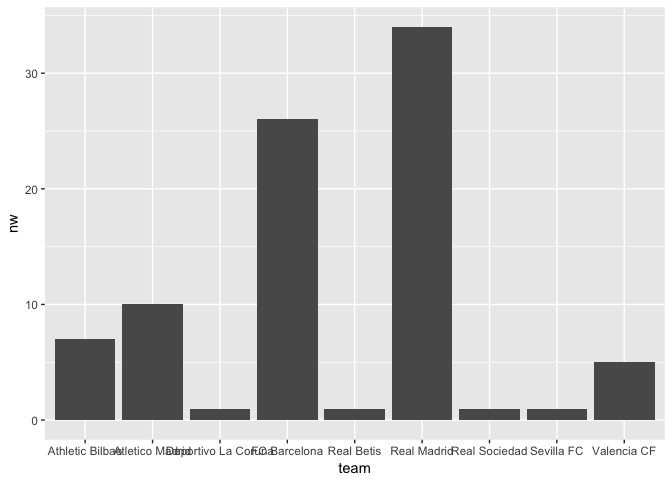

```r
p=ggplot()
p+geom_bar(data=atable , aes(x=team , y= nw),stat="identity")
```

۲. کسل کننده ترین لیگ و تیم را بیابید. نمودار ده تیم و ده فصل کسل کننده را رسم کنید.

# پاسخ

کسل کننده ترین تیم و لیگ تیم و لیگ هایی بودند که بیشترین تعداد نتیجه ی مساوی در آن ها وجود داشت. و سپس برای تیم ها تیمی که کمترین گل زده به ازای هر بازی را رد و بدل کرده بود . دو ستون تعداد مساوی ها و تعداد میانگین گل های رد و بدل شده را به داده هااضافه کردم و سپس بر حسب این دو سورت نمودم

```r
library(engsoccerdata)
library(highcharter)
library(ggplot2)
library(devtools)
library(dplyr)
data(package="engsoccerdata")
Laliga = as.tbl(spain)



rbind(
  Laliga %>%
    select(Season,Date, team = home, opp = visitor, GF = hgoal, GA = vgoal),
  Laliga %>%
    select(Season,Date, team = visitor, opp = home, GF = vgoal, GA = hgoal)
) %>% mutate(GS=GF+GA,GD = GF-GA, iswon=as.integer(GD>0) , islost=as.integer(GD<0) , isdrew=as.integer(GD==0)) %>%
  # group_by(Season) %>%
  arrange(Season, team, Date)->stats


stats %>%
  group_by(  Season,team ) %>%
  summarise(goalperplay=sum(GS)/n() , totd=sum(isdrew) ) %>%
  arrange(desc(totd),goalperplay) %>%
  .[1:10,] ->keselteam


keselteam%>%
  hchart(type = "column",hcaes(x = team,y = totd), name="Soccer")
```

[interactive chart not shown]

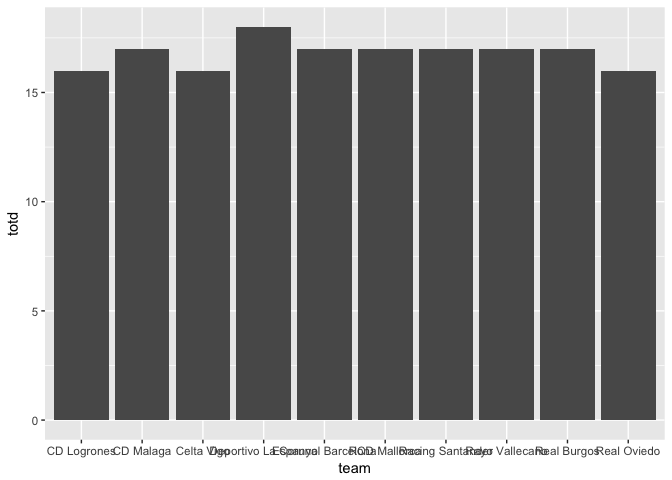

```r
p=ggplot ()
p+geom_bar(data=keselteam , aes(x=team , y= totd) , stat="identity")
```

```r
stats %>%
  group_by(Season) %>%
  summarise(goalperplay=sum(GS)/n() , totd=sum(isdrew) ) %>%
  arrange(desc(totd),goalperplay) %>%
  slice(1:10)->keselleag




keselteam%>%
  hchart(type = "column",hcaes(x = Season,y = totd), name="Soccer")
```

[interactive chart not shown]

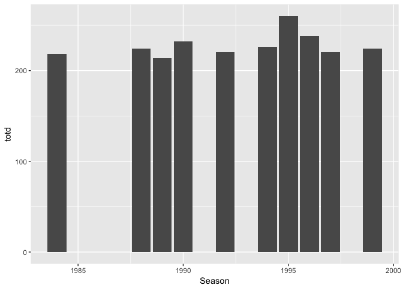

```r
p=ggplot()
p+geom_bar(data=keselleag , aes(x=Season , y= totd) , stat="identity")
```

۳. در چند درصد موارد قهرمان نیم فصل در پایان فصل قهرمان شده است؟

```r
library(engsoccerdata)
library(dplyr)
library(ggplot2)
library(highcharter)
data(package="engsoccerdata")
Laliga = as.tbl(spain)


rbind(
  Laliga %>%
    select(Season,Date, team = home, opp = visitor, GF = hgoal, GA = vgoal),
  Laliga %>%
    select(Season,Date, team = visitor, opp = home, GF = vgoal, GA = hgoal)
) %>% mutate(GD = GF-GA , score= 3*as.integer(GD>0)+1*as.integer(GD==0)+0*as.integer(GD<0))->stats

stats %>%
  group_by(Season, team ) %>%
  arrange(Date) %>%
  mutate(totscore=cumsum(score)) %>%
  group_by(Season, team ) %>%
  mutate (numnotplyd=n()-cumsum(as.integer(team==team))) %>%
  arrange(Season , (numnotplyd),desc(totscore)) %>%
  group_by(Season, numnotplyd) %>%
  mutate(rank=rank(-totscore)) ->newstat


newstat %>%
  group_by(Season , numnotplyd) %>%
  slice (1:1) %>%
  select (Season, team , totscore , numnotplyd , rank) ->df



cbind(

  df%>%
    group_by(Season) %>%
    slice(1) ,
  df %>%
    group_by(Season) %>%
    slice (1+(max(numnotplyd)+1)/2)

) %>%
  select(Season, team , team1  ) %>%
  arrange(Season) %>%
  mutate(issame=as.integer(team==team1))->df1



percent=sum(df1$issame)*100/length(df1$issame)

print(percent)
```

```
## [1] 52.32558
```

۴. در بین سال های ۲۰۰۱ تا ۲۰۱۰ گربه سیاه تیم های بزرگ چه تیم هایی بوده است؟

# پاسخ

دو تیم رئال مادرید و بارسلونا را به عنوان تیم های بزرگ در نر گرفته ام . سپس در بین ای نسال ها ۱۰ تیم اخر هر جدول را انتخاب کرده ام به عنوان تیم های ضعیف. سپس تعداد مسابقاتی که این تیم های ضعیف از تیم های قوی برنده شده اند را به دست آورده ام که در نمودار مشخص است

```r
library(engsoccerdata)
library(dplyr)
library(ggplot2)
library(highcharter)
data(package="engsoccerdata")
Laliga = as.tbl(spain)
Laliga %>%
  filter (Season %in% 2001:2010) ->Laliga1

rbind(
  Laliga1 %>%
    filter (home=="FC Barcelona" | home=="Real Madrid") %>%
    select(Season,Date, team = home, opp = visitor, GF = hgoal, GA = vgoal),
  Laliga1 %>%
    filter (home=="FC Barcelona" | home=="Real Madrid") %>%
    select(Season,Date, team = visitor, opp = home, GF = vgoal, GA = hgoal)
) %>% mutate(GD = GF-GA , score= 3*as.integer(GD>0)+1*as.integer(GD==0)+0*as.integer(GD<0))->stats


 rbind(
   Laliga %>%
     select(Season, team = home, opp = visitor, GF = hgoal, GA = vgoal),
    Laliga %>%
     select(Season, team = visitor, opp = home, GF = vgoal, GA = hgoal)
 ) %>%  mutate(GD = GF-GA) %>%
   group_by(Season, team) %>%
   summarize(GP = n(),
             goalsF = sum(GF),
             goalsA = sum(GA),
             goaldif = sum(GD),
             W = sum(GD>0),
             D = sum(GD==0),
             L = sum(GD<0)
   ) %>%
   mutate(score = W*3 + D) %>%
   mutate(rank = rank(-score) %>% as.integer()) %>%
   filter (Season %in% 2001:2010) %>%
   arrange(Season,rank) -> ltable
ltable %>%
  group_by(Season) %>%
  arrange(desc(rank)) %>%
  slice(1:10) %>%
  select(team , Season)->atable

df=data.frame(team=atable$team)
df %>% distinct(team, .keep_all = TRUE)->df


stats %>%
  filter(opp %in% df$team) %>%
  filter (score==0) %>%
  group_by(team, opp) %>%
 summarise(gamewon=n())->btable


btable %>%
  filter(team=="FC Barcelona") ->batable
batable%>%
  hchart(type = "column",hcaes(x = opp, y = gamewon))
```

[interactive chart not shown]

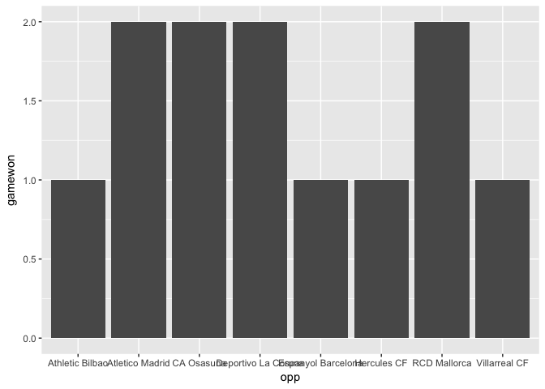

```r
p=ggplot(data=batable)
p+geom_bar(aes(x = opp, y = gamewon), stat="identity")
```

```r
btable %>%
  filter(team=="Real Madrid") ->bctable
bctable%>%
  hchart(type = "column",hcaes(x = opp, y = gamewon))
```

[interactive chart not shown]

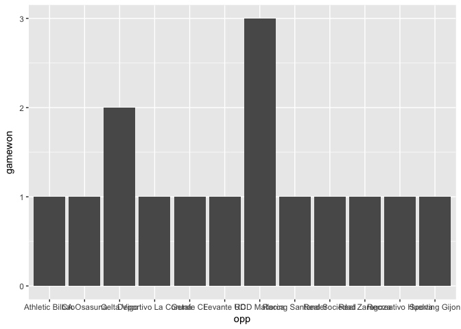

```r
p=ggplot(data=bctable)
p+geom_bar(aes(x = opp, y = gamewon), stat="identity")
```

۵. در تاریخ لالیگا کدام تیم رکورددار زودترین قهرمانی است؟ همچنین کدام تیم مقتدرانه ترین قهرمانی را داشته است؟

```r
library(engsoccerdata)
library(dplyr)
library(ggplot2)
library(highcharter)
data(package="engsoccerdata")
Laliga = as.tbl(spain)


rbind(
  Laliga %>%
    select(Season,Date, team = home, opp = visitor, GF = hgoal, GA = vgoal),
  Laliga %>%
    select(Season,Date, team = visitor, opp = home, GF = vgoal, GA = hgoal)
) %>% mutate(GD = GF-GA , score= 3*as.integer(GD>0)+1*as.integer(GD==0)+0*as.integer(GD<0))->stats

stats %>%
  group_by(Season, team ) %>%
  arrange(Date) %>%
  mutate(totscore=cumsum(score)) %>%
  group_by(Season, team ) %>%
  mutate (numnotplyd=n()-cumsum(as.integer(team==team))) %>%
  arrange(Season , (numnotplyd),desc(totscore)) %>%
  group_by(Season, numnotplyd) %>%
  mutate(rank=rank(-totscore)) ->newstat

newstat %>%
  group_by(Season, numnotplyd) %>%
  arrange(rank) %>%
  slice(1:2) %>%
  select(Season, team , numnotplyd , totscore) ->df

df %>%
  group_by(Season, numnotplyd) %>%
  mutate(a=max(totscore), b=min(totscore)) %>%
   mutate(scoredif=as.integer((a-b)>3*numnotplyd)) %>%
  slice(1:1) %>%
   select(Season , numnotplyd , scoredif , team ) %>%
   arrange(desc(scoredif) , desc(numnotplyd)) %>%
  select(Season , team , numnotplyd) %>% .[1:5,]->df2
print(df2)
```

```
## # A tibble: 5 x 3
## # Groups:   Season, numnotplyd [5]
##   Season team         numnotplyd
##    <dbl> <chr>             <int>
## 1   1960 Real Madrid           5
## 2   1962 Real Madrid           5
## 3   1973 FC Barcelona          5
## 4   1974 Real Madrid           5
## 5   1990 FC Barcelona          5
```

مقتدارنه ترین قهرمانی را قهرمانی با بیشترین تعداد برد درنظر گرفته ام.

```r
library(engsoccerdata)
library(dplyr)
library(ggplot2)
library(highcharter)
data(package="engsoccerdata")
Laliga = as.tbl(spain)



rbind(
  Laliga %>%
    select(Season,Date, team = home, opp = visitor, GF = hgoal, GA = vgoal),
  Laliga %>%
    select(Season,Date, team = visitor, opp = home, GF = vgoal, GA = hgoal)
) %>% mutate(GD = GF-GA, iswon=as.integer(GD>0) , islost=as.integer(GD<0) , isdrew=as.integer(GD==0)) %>%
  # group_by(Season) %>%
  arrange(Season, team, Date)->stats

rbind(
  Laliga %>%
    select(Season, team = home, opp = visitor, GF = hgoal, GA = vgoal),
  Laliga %>%
    select(Season, team = visitor, opp = home, GF = vgoal, GA = hgoal)
) %>% mutate(GD = GF-GA  ) %>%
  group_by(Season, team) %>%
  summarize(GP = n(),
            goalsF = sum(GF),
            goalsA = sum(GA),
            goaldif = sum(GD),
            W = sum(GD>0),
            D = sum(GD==0),
            L = sum(GD<0)
  ) %>%
  mutate(score = W*3 + D) %>%
  mutate(rank = rank(-score) %>% as.integer()) %>%
  arrange(rank) %>%
  group_by(Season) %>%
  slice(1:1) %>%
  arrange(-W) %>%
  .[1:10,]-> ltable


print(ltable)
```

```
## # A tibble: 10 x 11
## # Groups:   Season [10]
##    Season team      GP goalsF goalsA goaldif     W     D     L score  rank
##     <dbl> <chr>  <int>  <int>  <int>   <int> <int> <int> <int> <dbl> <int>
##  1   2011 Real ~    38    121     32      89    32     4     2 100       1
##  2   2012 FC Ba~    38    115     40      75    32     4     2 100       1
##  3   2009 FC Ba~    38     98     24      74    31     6     1  99.0     1
##  4   2010 FC Ba~    38     95     21      74    30     6     2  96.0     1
##  5   2014 FC Ba~    38    110     21      89    30     4     4  94.0     1
##  6   2015 FC Ba~    38    112     29      83    29     4     5  91.0     1
##  7   2016 Real ~    38    106     41      65    29     6     3  93.0     1
##  8   1987 Real ~    38     95     26      69    28     6     4  90.0     1
##  9   2013 Atlet~    38     77     26      51    28     6     4  90.0     1
## 10   1986 Real ~    44     84     37      47    27    12     5  93.0     1
```

سوال۶

```r
library(engsoccerdata)
library(highcharter)
library(devtools)
library(dplyr)
data(package="engsoccerdata")
Laliga = as.tbl(spain)



rbind(
  Laliga %>%
    select(Season,Date, team = home, opp = visitor, GF = hgoal, GA = vgoal),
  Laliga %>%
    select(Season,Date, team = visitor, opp = home, GF = vgoal, GA = hgoal)
) %>% mutate(GD = GF-GA, iswon=as.integer(GD>0) , islost=as.integer(GD<0) , isdrew=as.integer(GD==0)) %>%
 # group_by(Season) %>%
  arrange(Season, team, Date)->stats



maxcumone <- function(x) {
  l <- x == 1
  max(cumsum(l) - cummax(cumsum(l) * !l))
}


stats %>%
  group_by(Season,team) %>%
  summarise(maxwon=maxcumone(iswon) , maxlost=maxcumone(islost) , maxdrew=maxcumone(isdrew))->df

print( df[which.max(df$maxwon),] )
```

```
## # A tibble: 1 x 5
## # Groups:   Season [1]
##   Season team         maxwon maxlost maxdrew
##    <dbl> <chr>         <int>   <int>   <int>
## 1   2010 FC Barcelona     16       1       2
```

```r
print( df[which.max(df$maxlost),] )
```

```
## # A tibble: 1 x 5
## # Groups:   Season [1]
##   Season team          maxwon maxlost maxdrew
##    <dbl> <chr>          <int>   <int>   <int>
## 1   1959 UD Las Palmas      2      11       1
```

```r
print(df[which.max(df$maxdrew),])
```

```
## # A tibble: 1 x 5
## # Groups:   Season [1]
##   Season team      maxwon maxlost maxdrew
##    <dbl> <chr>      <int>   <int>   <int>
## 1   1978 Burgos CF      2       3       7
```

سوال۷

[output not shown]

[figure not shown]

```r
library(engsoccerdata)
library(dplyr)
library(ggplot2)
library(highcharter)
library(gridExtra)
data(package="engsoccerdata")
Laliga = as.tbl(spain)




rbind(
  Laliga %>%
    select(Season,Date, team = home, opp = visitor, GF = hgoal, GA = vgoal),
  Laliga %>%
    select(Season,Date, team = visitor, opp = home, GF = vgoal, GA = hgoal)
) %>% mutate(GD = GF-GA , score= 3*as.integer(GD>0)+1*as.integer(GD==0)+0*as.integer(GD<0))->stats

stats %>%
  group_by(Season, team ) %>%
  arrange(Date) %>%
  mutate(totscore=cumsum(score)) %>%
  group_by(Season, team ) %>%
  mutate (numnotplyd=n()-cumsum(as.integer(team==team))) %>%
  arrange(Season , (numnotplyd),desc(totscore)) %>%
  group_by(Season, numnotplyd) %>%
  mutate(rank=rank(-totscore)) ->newstat




newstat %>%
  group_by(Season, numnotplyd) %>%
  arrange(desc(rank)) %>%
  slice(3:4) %>%
  select(Season, team , numnotplyd , totscore) ->df



df %>%
  group_by(Season, numnotplyd) %>%
  mutate(a=max(totscore), b=min(totscore)) %>%
  mutate(scoredif=as.integer((a-b)>3*numnotplyd)) %>%
  slice(1:1) %>%
  select(Season , numnotplyd , scoredif , team ) %>%
  arrange(desc(scoredif) , desc(numnotplyd)) %>%
  select(Season , team , numnotplyd) ->df2
print(df2[1:3,])
```

مانند شکل بالا تصویری از روند تغییر رتبه تیم ها در طول فصل ۱۹۹۸ رسم نمایید.

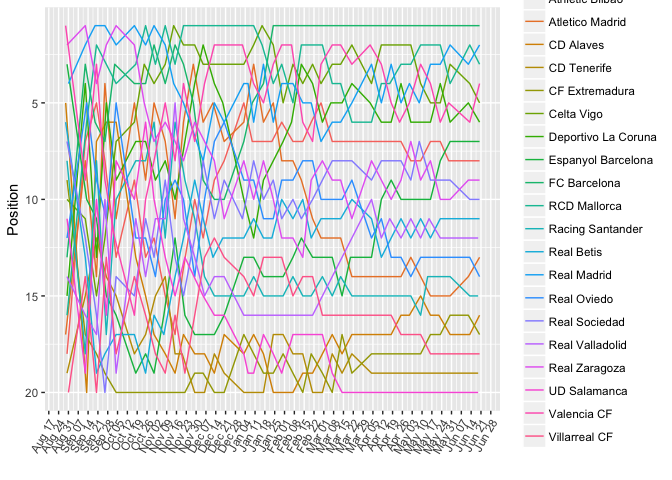

```r
library(engsoccerdata)
library(dplyr)
library(ggplot2)
library(highcharter)
library(gridExtra)
data(package="engsoccerdata")
Laliga = as.tbl(spain)


rbind(
  Laliga %>%
    select(Season,Date, team = home, opp = visitor, GF = hgoal, GA = vgoal),
  Laliga %>%
    select(Season,Date, team = visitor, opp = home, GF = vgoal, GA = hgoal)
) %>% mutate(GD = GF-GA , score= 3*as.integer(GD>0)+1*as.integer(GD==0)+0*as.integer(GD<0))->stats

stats %>%
  group_by(Season, team ) %>%
  arrange(Date) %>%
  mutate(totscore=cumsum(score)) %>%
  group_by(Season, team ) %>%
  mutate (numnotplyd=n()-cumsum(as.integer(team==team))) %>%
  arrange(Season , desc(numnotplyd),desc(totscore)) %>%
  group_by(Season, numnotplyd) %>%
  filter(Season==1998) %>%
  mutate(tmp=1, rank=cumsum(tmp)) %>%
  select(Season, Date , team , totscore, numnotplyd , rank ) ->newstat

newstat$Date = as.Date(newstat$Date, format='%Y-%m-%d')


p=ggplot(data= newstat , aes(x=Date , y=rank))
p+geom_line(aes(group=team , color=team )) + scale_y_reverse()+

  scale_x_date(date_breaks = "1 week", date_labels =  "%b %d")+
  theme(axis.text.x=element_text(angle=60, hjust=1)) +
  xlab(" ") + ylab("Position")
```

***

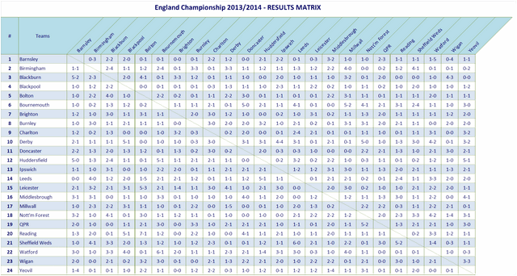

۹. جدولی مشابه بالا برای فصل ۲۰۱۲ از کل نتایج طراحی کنید.

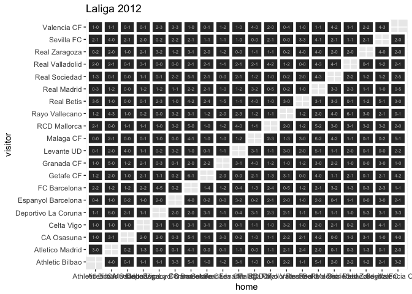

```r
library(engsoccerdata)
library(dplyr)
library(ggplot2)
library(highcharter)
library(gridExtra)
data(package="engsoccerdata")
Laliga = as.tbl(spain)

game1 = Laliga %>% filter( Season == "2012")
p=ggplot(game1, aes(home, visitor) )+
  geom_tile( color="white", size=1.5, stat="identity", height=1, width=1)  +
  geom_text(data=game1, aes(home, visitor, label = FT), color="grey", size=rel(2))

  p+ggtitle("Laliga 2012")
```

۱۰. سه آماره به همراه نمودار فردوسی پسند استخراج کنید.

# پاسخ

در این قسمت سعی کرده ام در دو نمودار مقایسه کنم که بازی هایی که تیم بارسلونا ازرئال مادرید برده را با چه تعداد گل و همچنین بازی هایی که رئال از بارسلونا برنده شده را باچه تعداد گل برده است.

```r
library(engsoccerdata)
library(dplyr)
library(ggplot2)
library(highcharter)
data(package="engsoccerdata")
Laliga = as.tbl(spain)




  Laliga %>%
    filter ((home=="FC Barcelona"  & visitor=="Real Madrid") | (home=="Real Madrid"  & visitor=="FC Barcelona")) %>%
    select(Season,Date, team = home, opp = visitor, GF = hgoal, GA = vgoal) %>%
    mutate (GD=GF-GA)->stats


  stats %>%
    filter(team== "FC Barcelona" & GD>0) %>%
    group_by(GD) %>%
    summarise(ngoaldif=n())%>%
    hchart(type = "column",hcaes(x = GD, y = ngoaldif),name = "score")
```

[interactive chart not shown]

```r
  stats %>%
    filter(team== "Real Madrid" & GD>0) %>%
    group_by(GD) %>%
    summarise(ngoaldif=n())%>%
    hchart(type = "column",hcaes(x = GD, y = ngoaldif),name = "score")
```

[interactive chart not shown]

تعداد کل گل های زده شده در لیگ ۲۰۱۶ را برای هر تیم به دست آورده ام .

```r
library(engsoccerdata)
library(dplyr)
library(ggplot2)
library(highcharter)
data(package="engsoccerdata")
Laliga = as.tbl(spain)


Laliga %>%
  filter(Season==2016) ->Laliga1

rbind(
  Laliga1%>%
    select(Season, team = home, opp = visitor, GF = hgoal),
  Laliga1 %>%
    select(Season, team = visitor, opp = home, GF = vgoal)
)  ->stat


stat %>%
  group_by(team ) %>%
  summarise (n=sum(GF)) %>%
  arrange(n)->newstat

hchart(newstat, type = "pie",hcaes(x = team, y = n), name = "goal")
```

[interactive chart not shown]

در اینجا میخواستم بررسی کنم که برای تیم قهرمان اگر بارسا باشد، برنده شدن در مسابقات با رئال رابطه ای با قهرمانی داشته است یا نه . تعداددفعاتی که بارسلونا هردوبازی رفت و برگشت با رئال را برده و یا بازی در خانه رئا را برده و هیچکدام یا فقط بازی در خانه خودش را برده تفکیک کرده ام در فصل هایی که بارسا قهرمان بوده و نمودار آن را رسم نموده ام.

```r
library(engsoccerdata)
library(dplyr)
library(ggplot2)
library(highcharter)
data(package="engsoccerdata")
Laliga = as.tbl(spain)



rbind(
  Laliga %>%
    select(Season, team = home, opp = visitor, GF = hgoal, GA = vgoal),
  Laliga %>%
    select(Season, team = visitor, opp = home, GF = vgoal, GA = hgoal)
) %>% mutate(GD = GF-GA) %>%
  group_by(Season, team) %>%
  summarize(GP = n(),
            goalsF = sum(GF),
            goalsA = sum(GA),
            goaldif = sum(GD),
            W = sum(GD>0),
            D = sum(GD==0),
            L = sum(GD<0)
  ) %>%
  mutate(score = W*3 + D) %>%
  mutate(rank = rank(-score) %>% as.integer()) %>%
  arrange(rank) %>%
  filter (rank==1 & team =="FC Barcelona")-> ltable

Laliga %>%
  filter ((home=="FC Barcelona"  & visitor=="Real Madrid")) %>%
  filter (Season %in% ltable$Season) %>%
  select(Season,Date, team = home, opp = visitor, GF = hgoal, GA = vgoal) %>%
  mutate (GD=GF-GA) %>%
  mutate(iswonhome=as.integer (GD>0))->barcahome

Laliga %>%
  filter ((home=="Real Madrid"  & visitor=="FC Barcelona")) %>%
  filter (Season %in% ltable$Season) %>%
  select(Season,Date, team = visitor, opp = home, GF = hgoal, GA = vgoal) %>%
  mutate (GD=GF-GA) %>%
  mutate(iswonvis=as.integer (GD>0))->barcavisitor


df= data.frame (Season=barcahome$Season )
c=as.integer(length(as.matrix(df[,1])))

for ( i in 1:c){


 if (barcahome[i,8]==1 &barcavisitor[i,8]==0) {
   df[i,2]="both"
 }

  else if (barcahome[i,8]==0 & barcavisitor[i,8]==1) {

    df[i,2]="visitor"

  }

  else {

    df[i,2]="none or won at home"

  }


}
df %>%
  group_by(V2) %>%
  summarise(per=n()) %>%
  hchart(type = "pie",hcaes(x =V2 , y = per), name = "Barca-Real") %>%
  hc_add_theme(hc_theme_538())
```

[interactive chart not shown]